# Prácticas4 Liga Github1

### Histogramas

Ejemplo con los datos islands (viene con R)

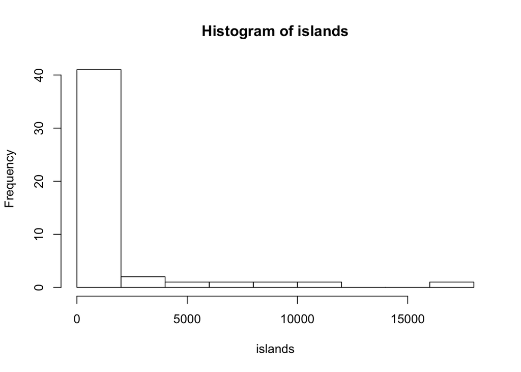

```r
hist(islands)
```

**Ejercicio** En “Unidad3/PracUni3/data/reads.txt” encontrarás un archivo con la cantidad de lecturas de las muestras de tres librerías que fueron secuenciadas en Illumina. Grafica un histograma de las lecturas de cada muestra.

### Barplot

Ejemplo:

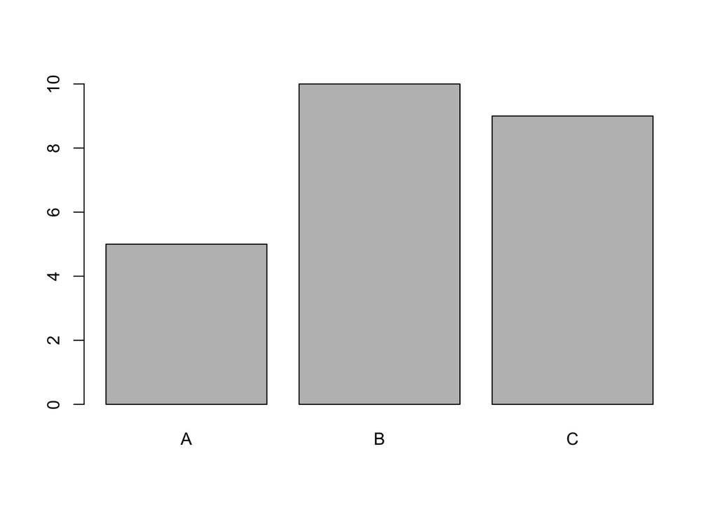

```r
DNAcon<-data.frame(muestra=c("A", "B", "C"), concentracionADN=c(5,10,9))
barplot(DNAcon$concentracionADN, names.arg=DNAcon$muestra)
```

**Ejercicio** Repite la gráfica de DNAcon pero agregando títulos a los ejes x,y

Ahora cargemos un archivo real de datos:

```r
reads<-read.delim("P4reads.txt")
```

Hagamos una gráfica de barras y colorear acorde a info contenida en otra columna:

```r
head(reads)
```

```
##   Library    sample  nreads
## 1    Lib1  pobA21_r 1381230
## 2    Lib1    pobB10 1726622
## 3    Lib1    pobB05  819766
## 4    Lib1    pobC05  442508
## 5    Lib1  pobD21_r 1398874
## 6    Lib1 Outa112_r 2024684
```

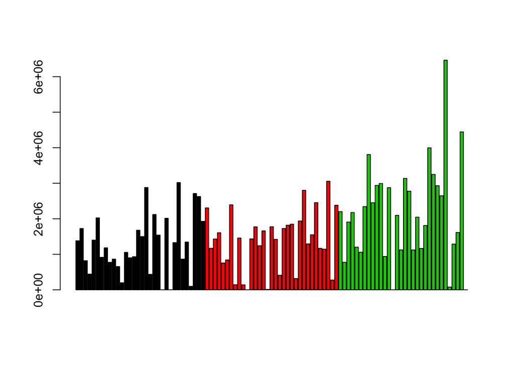

```r
barplot(reads$nreads, col=reads$Library)
```

### Definir colores

Los colores que R ocupa para colorear algo están definidos en `palette` y pueden cambiarse

```r
# Ver colores
palette()
```

```
## [1] "black"   "red"     "green3"  "blue"    "cyan"    "magenta" "yellow"
## [8] "gray"
```

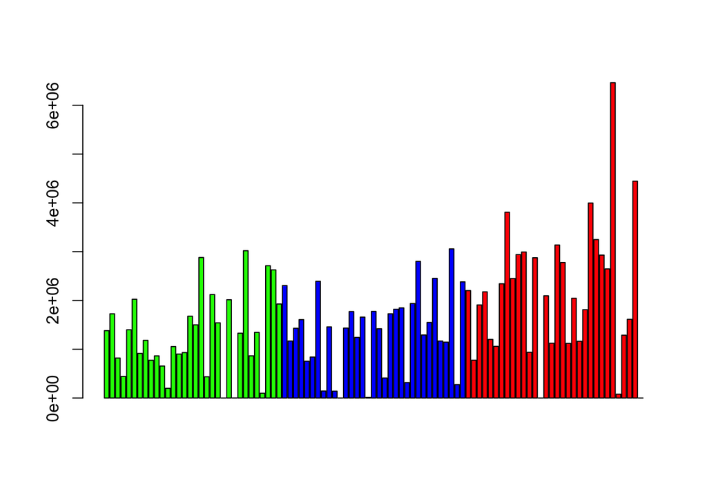

```r
# Cambiar colores
palette(c("green", "blue", "red"))
# volver a graficar
barplot(reads$nreads, col=reads$Library)
```

Además de manualmente, los colores se pueden definir via paletas predeterminadas:

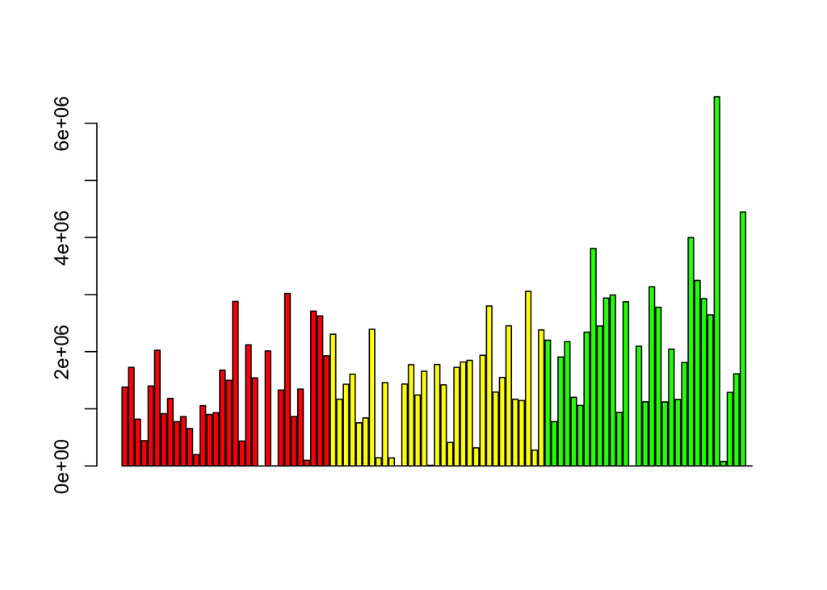

```r
# Cambiar palette a 6 colores del arcoiris
palette(rainbow(6))
# volver a graficar
barplot(reads$nreads, col=reads$Library)
```

### Agregar una leyenda

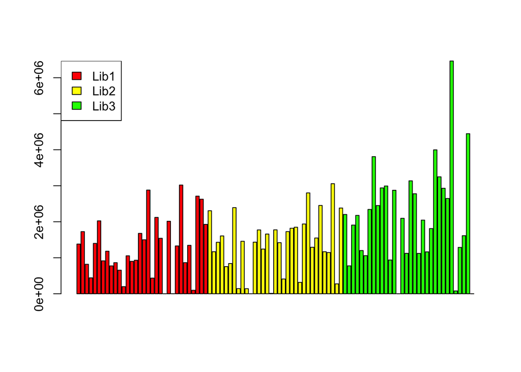

```r
# Graficar
barplot(reads$nreads, col=reads$Library)
# Agregar leyenda
legend(x="topleft", legend=levels(reads$Library), fill=palette()[1:3])
```

Nota que `legend` es una función por si misma (i.e. NO un argumento de `plot`) que requiere que antes de correrlo se haya corrido `plot`. Es decir una vez que creamos una gráfica podemos **agregar sobre de esta** una leyenda. Lo mismo puede hacerse con la función `title`.

## ggplot2

Las gráficas que hemos visto hasta ahora pueden verse un poco feas de inicio y puede tomar un rato y mucho código arreglarlas a algo hermoso. `ggplot2` es un paquete que ahorra este trabajo y que ahora es ampliamente adoptado.

`ggplot2` construye gráficas “definiendo sus componentes paso a paso”.

Para poder usar `ggplot2` se requiere que la data.frame esté en **formato largo**, como vimos cuando revisamos la función `gather`. Además de esos apuntes puedes revisar [esto](http://www.cookbook-r.com/Manipulating_data/Converting_data_between_wide_and_long_format/) si te quedan dudas.

```r
# Cargar ggplot2
library(ggplot2)
# Examinar datos pre-cargados
head(iris)
```

```
##   Sepal.Length Sepal.Width Petal.Length Petal.Width Species
## 1          5.1         3.5          1.4         0.2  setosa
## 2          4.9         3.0          1.4         0.2  setosa
## 3          4.7         3.2          1.3         0.2  setosa
## 4          4.6         3.1          1.5         0.2  setosa
## 5          5.0         3.6          1.4         0.2  setosa
## 6          5.4         3.9          1.7         0.4  setosa
```

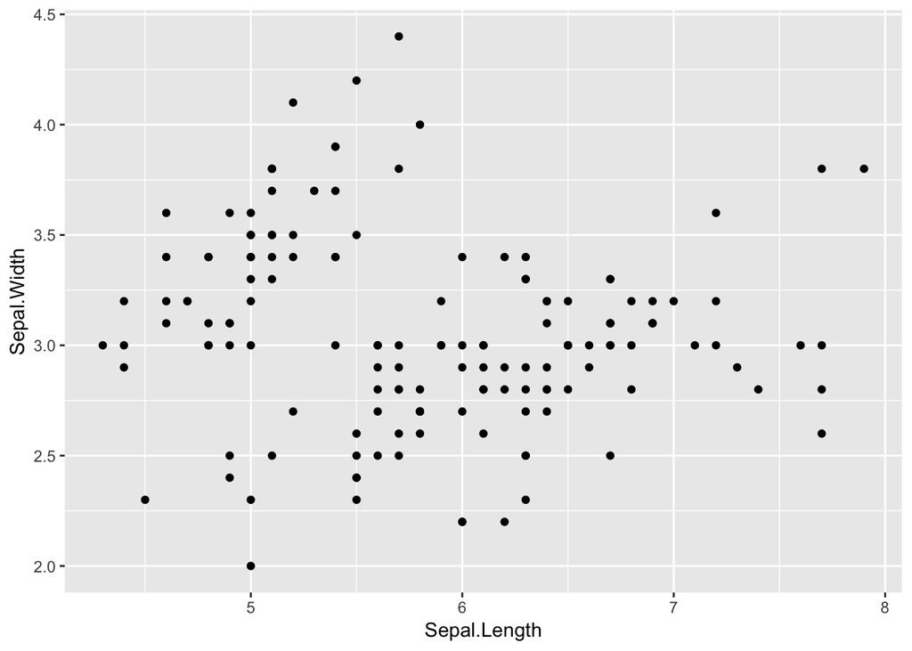

```r
# graficar
ggplot(data=iris, aes(x=Sepal.Length, y= Sepal.Width)) + geom_point()
```

**Pregunta:** ¿Qué hace el símbolo +? Nota que el código anterior tmb puede escribirse así:

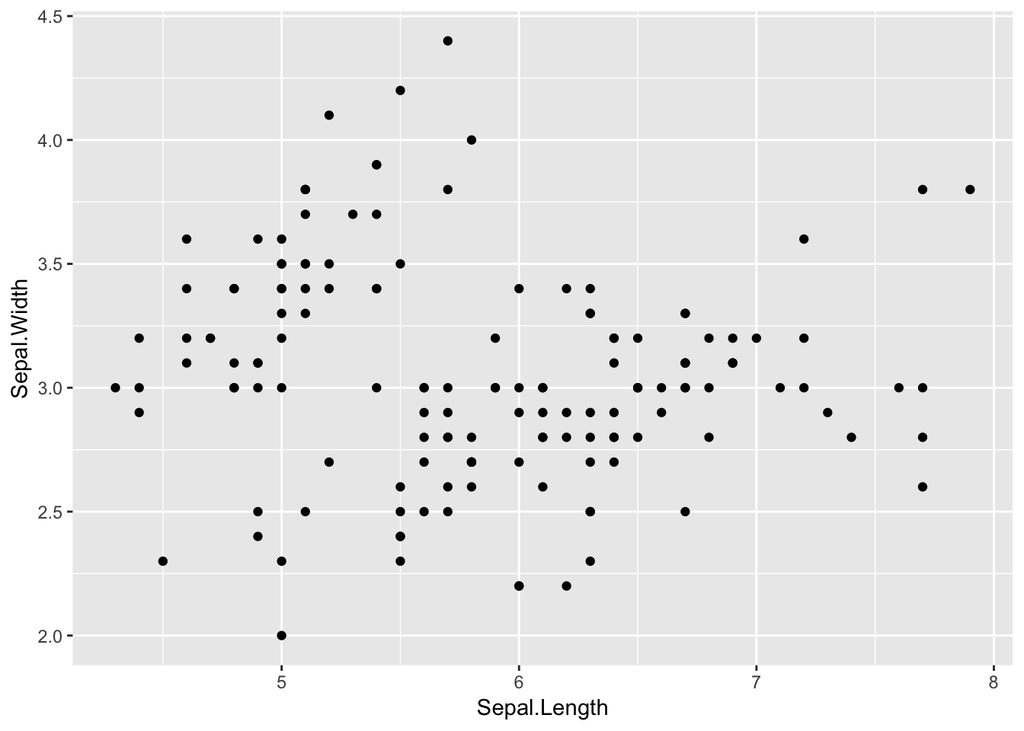

```r
myplot<-ggplot(data=iris, aes(x=Sepal.Length, y= Sepal.Width))
myplot + geom_point()
```

Los colores y formas se cambian en **aes**:

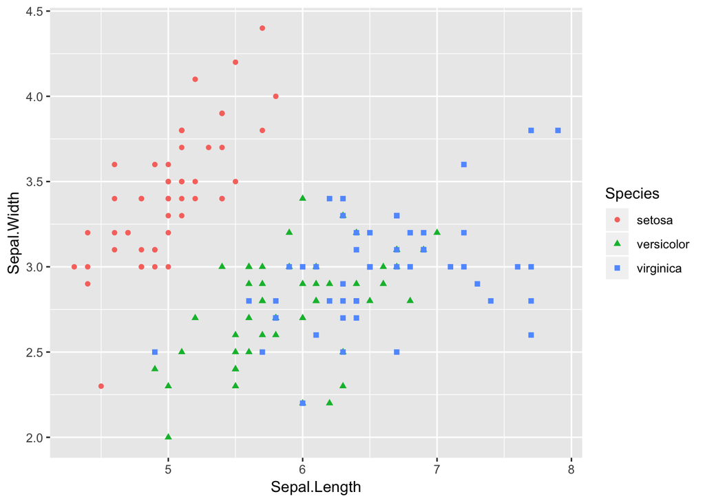

```r
ggplot(data=iris, aes(x=Sepal.Length, y= Sepal.Width, color= Species, shape=Species)) + geom_point()
```

Ya sea en el aes de la función inicial o dentro de los geoms (Nota que el tamaño no es un aes, sino un argumento de geom_point)

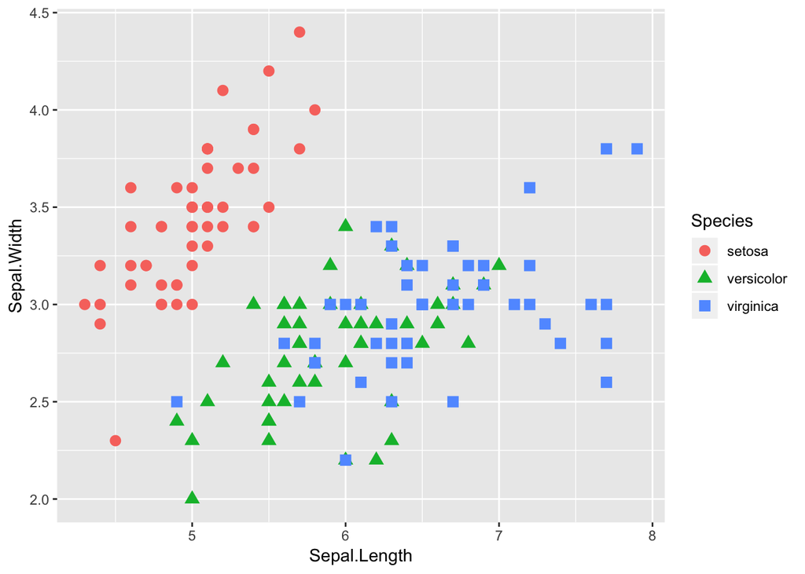

```r
ggplot(data=iris, aes(x=Sepal.Length, y= Sepal.Width)) +
    geom_point(aes(color= Species, shape=Species), size=3)
```

Si queremos quitar el fondo gris:

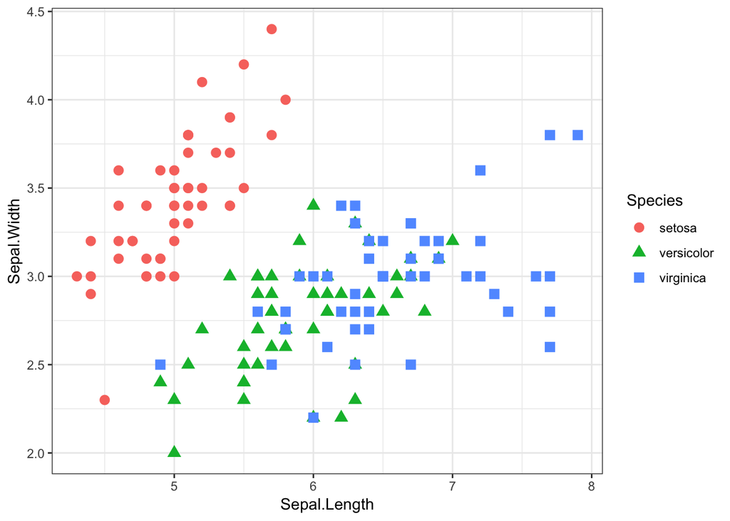

```r
ggplot(data=iris, aes(x=Sepal.Length, y= Sepal.Width)) +
    geom_point(aes(color= Species, shape=Species), size=3) +
    theme_bw()
```

Aveces queremos graficar en páneles separados la misma info para diferentes tratamientos o especies. Por ejemplo:

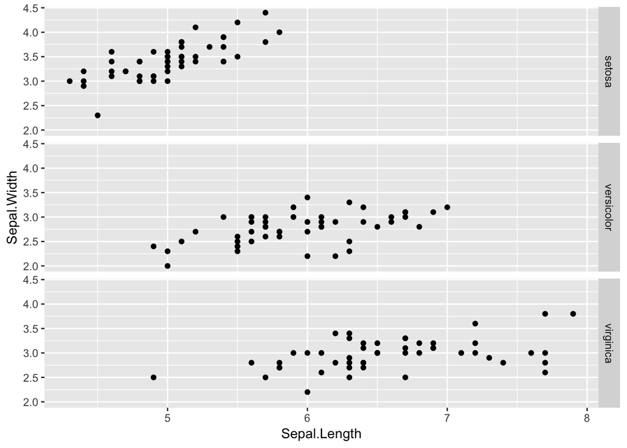

```r
ggplot(data=iris, aes(x=Sepal.Length, y= Sepal.Width)) +
  geom_point() +
  facet_grid(Species ~ .)
```

**Ejercicio** Pon color por especie a la gráfica anterior:

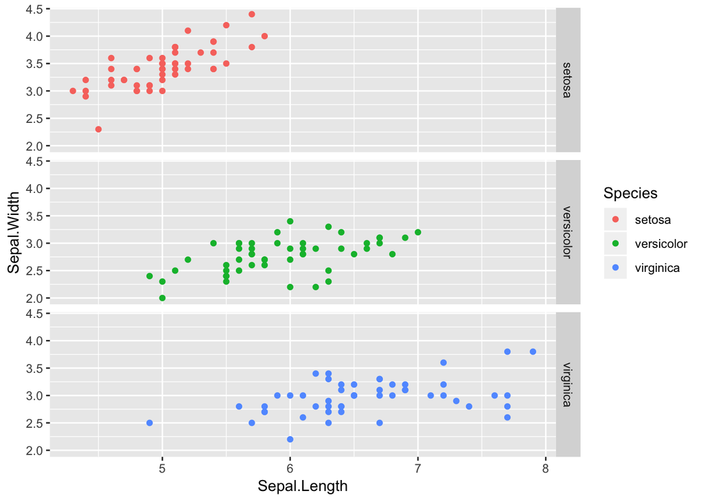

**Ejercicio** Repite la gráfica anterior pero para que se vea así:

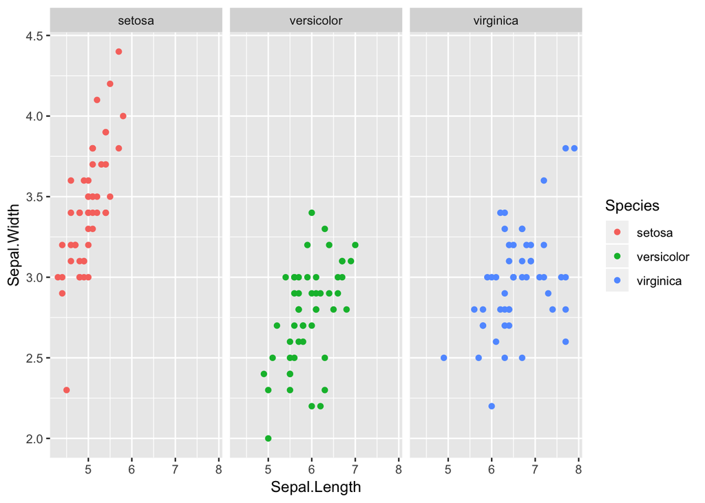

**Ejercicio** Repite la figura anterior pero cambiando los labels para que digan “Ancho de sépalo” y “Largo de sépalo”, respectivamente. Debe verse así:

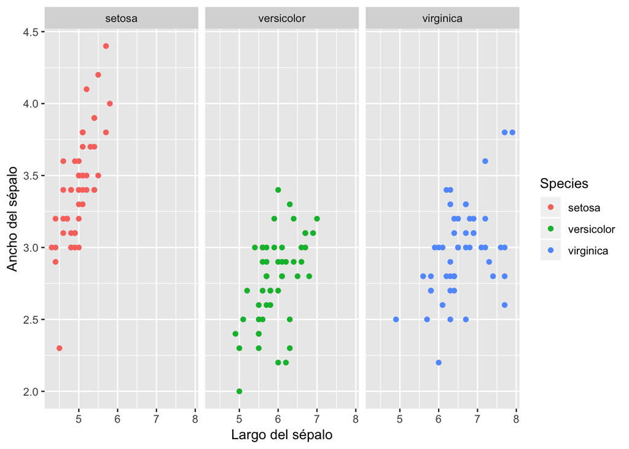

También podemos agregar el resultado de un modelo matemático, como una regresión lineal:

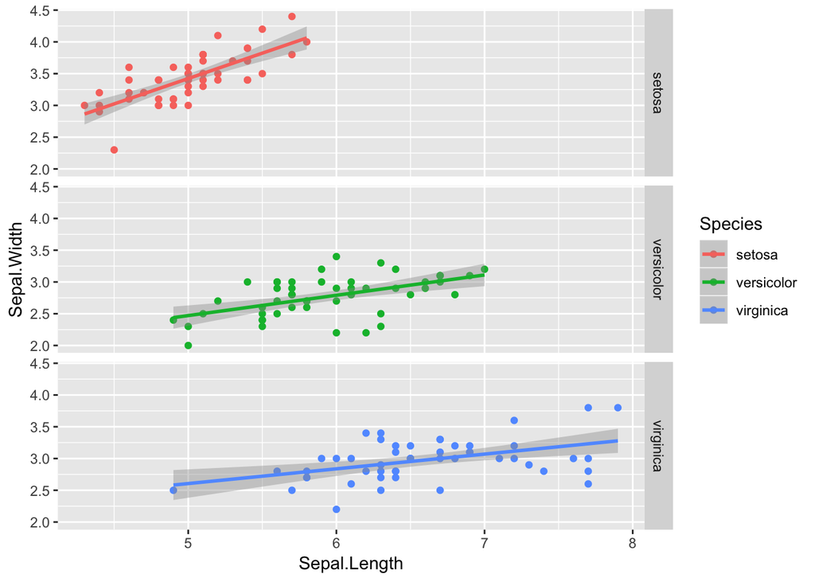

```r
ggplot(data=iris, aes(x=Sepal.Length, y= Sepal.Width, color=Species)) +
  geom_point() +
  facet_grid(Species ~ .) +
  geom_smooth(method="lm")
```